# Spectrum disorder

From Wikipedia, the free encyclopedia

[output not shown]

A **spectrum disorder** is a [disorder](https://en.wikipedia.org/wiki/Disease#Disorder) that includes a range of linked conditions, sometimes also extending to include singular symptoms and [traits](https://en.wikipedia.org/wiki/Trait_theory). The different elements of a spectrum either have a similar appearance or are thought to be caused by the same underlying mechanism. In either case, a spectrum approach is taken because there appears to be "not a unitary disorder but rather a [syndrome](https://en.wikipedia.org/wiki/Syndrome) composed of subgroups". The spectrum may represent a range of severity, comprising relatively "severe" [mental disorders](https://en.wikipedia.org/wiki/Mental_disorders) through to relatively "mild and nonclinical [deficits](https://en.wikipedia.org/wiki/Cognitive_deficit)".<sup>[1]</sup>

In some cases, a spectrum approach joins conditions that were previously considered separately. A notable example of this trend is the [autism spectrum](https://en.wikipedia.org/wiki/Autism_spectrum), where conditions on this spectrum may now all be referred to as autism spectrum disorders. A spectrum approach may also expand the type or the severity of issues which are included, which may lessen the gap with other diagnoses or with what is considered "normal". Proponents of this approach argue that it is in line with evidence of gradations in the type or severity of symptoms in the general population.

## Origin[[edit](https://en.wikipedia.org/w/index.php?title=Spectrum_disorder&action=edit&section=1)]

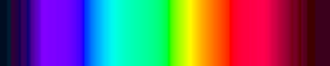

The visible color spectrum

The term [spectrum](https://en.wikipedia.org/wiki/Spectrum) was originally used in physics to indicate an apparent qualitative distinction arising from a [quantitative](https://en.wikipedia.org/wiki/Quantity) continuum (i.e. a series of distinct [colors](https://en.wikipedia.org/wiki/Color) experienced when a beam of [white light](https://en.wikipedia.org/wiki/White_light) is dispersed by a prism according to [wavelength](https://en.wikipedia.org/wiki/Wavelength)). [Isaac Newton](https://en.wikipedia.org/wiki/Isaac_Newton) first used the word *spectrum* (Latin for "appearance" or "apparition") in print in 1671, in describing his experiments in [optics](https://en.wikipedia.org/wiki/Optics).

The term was first used by [analogy](https://en.wikipedia.org/wiki/Analogy) in [psychiatry](https://en.wikipedia.org/wiki/Psychiatry) with a slightly different connotation, to identify a group of conditions that is qualitatively distinct in appearance but believed to be related from an underlying pathogenic point of view. It has been noted that for clinicians trained after the publication of DSM-III (1980), the spectrum concept in psychiatry may be relatively new, but that it has a long and distinguished history that dates back to [Emil Kraepelin](https://en.wikipedia.org/wiki/Emil_Kraepelin) and beyond.<sup>[1]</sup> A dimensional concept was proposed by [Ernst Kretschmer](https://en.wikipedia.org/wiki/Ernst_Kretschmer) in 1921 for schizophrenia ([schizothymic](https://en.wikipedia.org/wiki/Schizothymic) – [schizoid](https://en.wikipedia.org/wiki/Schizoid) – [schizophrenic](https://en.wikipedia.org/wiki/Schizophrenic)) and for affective disorders ([cyclothymic](https://en.wikipedia.org/wiki/Cyclothymic) temperament – [cycloid](https://en.wikipedia.org/wiki/Cycloid) '[psychopathy](https://en.wikipedia.org/wiki/Psychopathy)' – [manic-depressive disorder](https://en.wikipedia.org/wiki/Manic-depressive_disorder)), as well as by [Eugen Bleuler](https://en.wikipedia.org/wiki/Eugen_Bleuler) in 1922. The term "spectrum" was first used in psychiatry in 1968 in regard to a postulated schizophrenia spectrum, at that time meaning a linking together of what were then called "[schizoid](https://en.wikipedia.org/wiki/Schizoid) personalities", in people diagnosed with schizophrenia and their genetic relatives (see [Seymour S. Kety](https://en.wikipedia.org/wiki/Seymour_S._Kety)).<sup>[2]</sup>

For different investigators, the hypothetical common [disease-causing](https://en.wikipedia.org/wiki/Pathogenesis) link has been of a different nature.<sup>[1]</sup>

## Related concepts[[edit](https://en.wikipedia.org/w/index.php?title=Spectrum_disorder&action=edit&section=2)]

A spectrum approach generally overlays or extends a *categorical* approach, which today is most associated with the [Diagnostic and Statistical Manual of Mental Disorders](https://en.wikipedia.org/wiki/Diagnostic_and_Statistical_Manual_of_Mental_Disorders) (DSM) and [International Statistical Classification of Diseases](https://en.wikipedia.org/wiki/International_Statistical_Classification_of_Diseases) (ICD). In these diagnostic guides, disorders are considered present if there is a certain combination and number of symptoms. Gradations of present versus absent are not allowed, although there may be subtypes of severity within a category. The categories are also polythetic, because a constellation of symptoms is laid out and different patterns of them can qualify for the same diagnosis. These categories are aids important for our practical purposes such as providing specific labels to facilitate payments for [mental health professionals](https://en.wikipedia.org/wiki/Mental_health_professionals). They have been described as clearly worded, with observable criteria, and therefore an advance over some previous models for research purposes.<sup>[3]</sup>

A spectrum approach sometimes starts with the nuclear, classic DSM diagnostic criteria for a disorder (or may join several disorders), and then include an additional broad range of issues such as temperaments or traits, lifestyle, behavioral patterns, and personality characteristics.<sup>[1]</sup>

In addition, the term 'spectrum' may be used interchangeably with continuum, although the latter goes further in suggesting a direct straight line with no significant discontinuities. Under some continuum models, there are no set types or categories at all, only different dimensions along which everyone varies (hence a *dimensional* approach).

An example can be found in personality or [temperament](https://en.wikipedia.org/wiki/Temperament) models. For example, a model that was derived from linguistic expressions of individual differences is subdivided into the [Big Five personality traits](https://en.wikipedia.org/wiki/Big_Five_personality_traits), where everyone can be assigned a score along each of the five dimensions. This is by contrast to models of '[personality types](https://en.wikipedia.org/wiki/Personality_types)' or temperament, where some have a certain type and some do not. Similarly, in the [classification of mental disorders](https://en.wikipedia.org/wiki/Classification_of_mental_disorders), a dimensional approach, which is being considered for the DSM-V, would involve everyone having a score on personality trait measures. A categorical approach would only look for the presence or absence of certain clusters of symptoms, perhaps with some cut-off points for severity for some symptoms only, and as a result diagnose some people with [personality disorders](https://en.wikipedia.org/wiki/Personality_disorder).<sup>[4]</sup><sup>[5]</sup>

A spectrum approach, by comparison, suggests that although there is a common underlying link, which could be continuous, particular sets of individuals present with particular patterns of symptoms (i.e. syndrome or subtype), reminiscent of the [visible spectrum](https://en.wikipedia.org/wiki/Visible_spectrum) of distinct colors after refraction of light by a prism.<sup>[1]</sup>

It has been argued that within the data used to develop the DSM system there is a large literature leading to the conclusion that a spectrum classification provides a better perspective on phenomenology (appearance and experience) of [psychopathology](https://en.wikipedia.org/wiki/Psychopathology) (mental difficulties) than a categorical classification system. However, the term has a varied history, meaning one thing when referring to a schizophrenia spectrum and another when referring to bipolar or obsessive–compulsive disorder spectrum, for example.<sup>[1]</sup>

## Types of spectrum[[edit](https://en.wikipedia.org/w/index.php?title=Spectrum_disorder&action=edit&section=3)]

The widely used [DSM](https://en.wikipedia.org/wiki/Diagnostic_and_Statistical_Manual_of_Mental_Disorders) and [ICD](https://en.wikipedia.org/wiki/International_Classification_of_Diseases) manuals are generally limited to categorical diagnoses. However, some categories include a range of subtypes which vary from the main diagnosis in clinical presentation or typical severity. Some categories could be considered subsyndromal (not meeting criteria for the full diagnosis) subtypes. In addition, many of the categories include a '[not otherwise specified](https://en.wikipedia.org/wiki/Not_otherwise_specified#Not_Otherwise_Specified)' subtype, where enough symptoms are present but not in the main recognized pattern; in some categories this is the most common diagnosis.

Spectrum concepts used in research or clinical practice include the following.<sup>[1]</sup>

### Anxiety, stress, and dissociation[[edit](https://en.wikipedia.org/w/index.php?title=Spectrum_disorder&action=edit&section=4)]

Several types of spectrum are in use in these areas, some of which are being considered in the DSM-5.<sup>[6]</sup>

A [generalized anxiety](https://en.wikipedia.org/wiki/Generalized_anxiety) spectrum<sup>[7]</sup> – this spectrum has been defined by duration of symptoms: a type lasting over six months (a DSM-IV criterion), over one month (DSM-III), or lasting two weeks or less (though may recur), and also isolated anxiety symptoms not meeting criteria for any type.

A [social anxiety](https://en.wikipedia.org/wiki/Social_anxiety) spectrum<sup>[8]</sup> – this has been defined to span [shyness](https://en.wikipedia.org/wiki/Shyness) to [social anxiety disorder](https://en.wikipedia.org/wiki/Social_anxiety_disorder), including typical and atypical presentations, isolated signs and symptoms, and elements of [avoidant personality disorder](https://en.wikipedia.org/wiki/Avoidant_personality_disorder).

A [panic](https://en.wikipedia.org/wiki/Panic_disorder)-[agoraphobia](https://en.wikipedia.org/wiki/Agoraphobia) spectrum<sup>[9]</sup> – due to the [heterogeneity](https://en.wikipedia.org/wiki/Heterogeneity) (diversity) found in individual clinical presentations of panic disorder and agoraphobia, attempts have been made to identify symptom clusters in addition to those included in the DSM diagnoses, including through the development of a dimensional questionnaire measure.

A [post-traumatic stress](https://en.wikipedia.org/wiki/Post-traumatic_stress) spectrum<sup>[10]</sup> or trauma and [loss](https://en.wikipedia.org/wiki/Grief) spectrum<sup>[11]</sup> – work in this area has sought to go beyond the DSM category and consider in more detail a spectrum of severity of symptoms (rather than just presence or absence for diagnostic purposes), as well as a spectrum in terms of the nature of the stressor (e.g. the traumatic incident) and a spectrum of how people respond to trauma. This identifies a significant amount of symptoms and impairment below threshold for DSM diagnosis but nevertheless important, and potentially also present in other disorders a person might be diagnosed with.

A [depersonalization](https://en.wikipedia.org/wiki/Depersonalization)-[derealization](https://en.wikipedia.org/wiki/Derealization) spectrum<sup>[12]</sup><sup>[13]</sup> – although the DSM identifies only a chronic and severe form of [depersonalization derealization disorder](https://en.wikipedia.org/wiki/Depersonalization-derealization_disorder), and the ICD a 'depersonalization-derealization syndrome', a spectrum of severity has long been identified, including short-lasting episodes commonly experienced in the general population and often associated with other disorders.

### Obsessions and compulsions[[edit](https://en.wikipedia.org/w/index.php?title=Spectrum_disorder&action=edit&section=5)]

An [obsessive–compulsive spectrum](https://en.wikipedia.org/wiki/Obsessive%E2%80%93compulsive_spectrum)<sup>[14]</sup> – this can include a wide range of disorders from [Tourette syndrome](https://en.wikipedia.org/wiki/Tourette_syndrome) to the [hypochondrias](https://en.wikipedia.org/wiki/Hypochondrias), as well as forms of [eating disorder](https://en.wikipedia.org/wiki/Eating_disorder), itself a spectrum of related conditions.<sup>[15]</sup>

### General developmental disorders[[edit](https://en.wikipedia.org/w/index.php?title=Spectrum_disorder&action=edit&section=6)]

An autistic spectrum<sup>[16]</sup> – in its simplest form this joins [autism](https://en.wikipedia.org/wiki/Autism) and [Asperger syndrome](https://en.wikipedia.org/wiki/Asperger_syndrome), and can additionally include other [pervasive developmental disorders](https://en.wikipedia.org/wiki/Pervasive_developmental_disorders) (PDD). These include [PDD 'not otherwise specified'](https://en.wikipedia.org/wiki/Pervasive_developmental_disorder_not_otherwise_specified) (including 'atypical autism'), as well as [Rett syndrome](https://en.wikipedia.org/wiki/Rett_syndrome) and [childhood disintegrative disorder](https://en.wikipedia.org/wiki/Childhood_disintegrative_disorder) (CDD). The first three of these disorders are commonly called the autism spectrum disorders; the last two disorders are much rarer, and are sometimes placed in the autism spectrum and sometimes not.<sup>[17]</sup><sup>[18]</sup> The merging of these disorders is based on findings that the symptom profiles are similar, such that individuals are better differentiated by clinical specifiers (i.e. dimensions of severity, such as extent of social communication difficulties or how fixed or restricted behaviors or interests are) and associated features (e.g. known genetic disorders, epilepsy, intellectual disabilities). The term [specific developmental disorders](https://en.wikipedia.org/wiki/Specific_developmental_disorders) is reserved for categorizing particular specific [learning disabilities](https://en.wikipedia.org/wiki/Learning_disabilities) and developmental disorders affecting coordination.

### Schizophrenia spectrum[[edit](https://en.wikipedia.org/w/index.php?title=Spectrum_disorder&action=edit&section=7)]

See also: Schizotypy

The [schizophrenia](https://en.wikipedia.org/wiki/Schizophrenia) spectrum or [psychotic](https://en.wikipedia.org/wiki/Psychotic) spectrum<sup>[19]</sup><sup>[20]</sup><sup>[21]</sup> – there are numerous *psychotic spectrum disorders* already in the DSM, many involving reality distortion.<sup>[22]</sup> These include:

- Five subtypes of schizophrenia (although eliminated in DSM-5)
- Two forms of shorter duration ([schizophreniform disorder](https://en.wikipedia.org/wiki/Schizophreniform_disorder) and [brief psychotic disorder](https://en.wikipedia.org/wiki/Brief_psychotic_disorder))
- three delusional disorders (persistent [delusional disorder](https://en.wikipedia.org/wiki/Delusional_disorder), [shared psychotic disorder](https://en.wikipedia.org/wiki/Shared_psychotic_disorder), [other delusional disorders](https://en.wikipedia.org/w/index.php?title=Other_delusional_disorders&action=edit&redlink=1))
- [Schizoaffective disorder](https://en.wikipedia.org/wiki/Schizoaffective_disorder): symptoms of schizophrenia and a [mood disorder](https://en.wikipedia.org/wiki/Mood_disorder) ([depression](https://en.wikipedia.org/wiki/Major_depressive_disorder) or [bipolar disorder](https://en.wikipedia.org/wiki/Bipolar_disorder))
- Catatonia
- [Schizotypal personality disorder](https://en.wikipedia.org/wiki/Schizotypal_personality_disorder)
- [Other and unspecified non-organic psychotic disorders](https://en.wikipedia.org/w/index.php?title=Other_and_unspecified_non-organic_psychotic_disorders&action=edit&redlink=1) (Atypical psychosis), (inc: chronic hallucinatory psychosis)

[Predisposition](https://en.wikipedia.org/wiki/Genetic_predisposition) to schizophrenia is classified with the neologism schizotaxia.<sup>[23]</sup> There are also traits identified in first degree relatives of those diagnosed with schizophrenia associated with the spectrum.<sup>[24]</sup> Other spectrum approaches include more specific individual phenomena which may also occur in non-clinical forms in the general population, such as some paranoid beliefs or hearing voices. Psychosis accompanied by mood disorder may be included as a schizophrenia spectrum disorder, or may be classed separately as below.

Schizophrenia spectrum disorders do not necessarily involve psychotic symptoms. [Schizoid personality disorder](https://en.wikipedia.org/wiki/Schizoid_personality_disorder), [schizotypal personality disorder](https://en.wikipedia.org/wiki/Schizotypal_personality_disorder), and [paranoid personality disorder](https://en.wikipedia.org/wiki/Paranoid_personality_disorder) can be considered 'schizophrenia-like personality disorders' because of their similarities to the schizophrenia spectrum.<sup>[25]</sup> Some researchers have also proposed that avoidant personality disorder and related [social anxiety](https://en.wikipedia.org/wiki/Social_anxiety) traits should be considered part of a schizophrenia spectrum.<sup>[26]</sup>

From a [psychodynamic](https://en.wikipedia.org/wiki/Psychodynamic) or [psychoanalytic](https://en.wikipedia.org/wiki/Psychoanalytic) perspective, the distinction between schizoid, schizotypal and avoidant personality disorders is sometimes considered inconsequential, as these disorders are understood to share similar experiential characteristics and be differentiated chiefly by surface-level observations about behavioral differences.<sup>[27]</sup><sup>[28]</sup> Psychotic disorders such as schizophrenia and schizoaffective disorders are then thought to be the psychotic expression of a shared underlying personality structure.<sup>[27]</sup>

#### Schizoaffective disorders[[edit](https://en.wikipedia.org/w/index.php?title=Spectrum_disorder&action=edit&section=8)]

A [schizoaffective](https://en.wikipedia.org/wiki/Schizoaffective) spectrum<sup>[29]</sup><sup>[30]</sup> – this spectrum refers to features of both [psychosis](https://en.wikipedia.org/wiki/Psychosis) ([hallucinations](https://en.wikipedia.org/wiki/Hallucinations), [delusions](https://en.wikipedia.org/wiki/Delusions), [thought disorder](https://en.wikipedia.org/wiki/Thought_disorder) etc.) and [mood disorder](https://en.wikipedia.org/wiki/Mood_disorder) (see below). The DSM has, on the one hand, a category of schizoaffective disorder (which may be more [affective](https://en.wikipedia.org/wiki/Affective) (mood) or more schizophrenic), and on the other hand psychotic bipolar disorder and [psychotic depression](https://en.wikipedia.org/wiki/Psychotic_depression) categories. A spectrum approach joins these together and may additionally include specific clinical variables and outcomes, which initial research suggested may not be particularly well captured by the different diagnostic categories except at the extremes.

### Mood[[edit](https://en.wikipedia.org/w/index.php?title=Spectrum_disorder&action=edit&section=9)]

A [mood disorder](https://en.wikipedia.org/wiki/Mood_disorder) ([affective](https://en.wikipedia.org/wiki/Affective)) spectrum<sup>[31]</sup> or bipolar spectrum<sup>[2]</sup> or depressive spectrum.<sup>[32]</sup> These approaches have expanded out in different directions. On the one hand, work on [major depressive disorder](https://en.wikipedia.org/wiki/Major_depressive_disorder) has identified a spectrum of subcategories and sub-threshold symptoms that are prevalent, recurrent and associated with treatment needs. People are found to move between the subtypes and the main diagnostic type over time, suggesting a spectrum. This spectrum can include already recognised categories of [minor depressive disorder](https://en.wikipedia.org/wiki/Minor_depressive_disorder), '[melancholic depression](https://en.wikipedia.org/wiki/Melancholic_depression)' and various kinds of [atypical depression](https://en.wikipedia.org/wiki/Atypical_depression).

In another direction, numerous links and overlaps have been found between major depressive disorder and bipolar syndromes, including mixed states (simultaneous depression and [mania](https://en.wikipedia.org/wiki/Mania) or [hypomania](https://en.wikipedia.org/wiki/Hypomania)). Hypomanic ('below manic') and more rarely manic signs and symptoms have been found in a significant number of cases of major depressive disorder, suggesting not a categorical distinction but a dimension of frequency that is higher in bipolar II and higher again in bipolar I.<sup>[33]</sup> In addition, numerous subtypes of bipolar have been proposed beyond the types already in the DSM (which includes a milder form called [cyclothymia](https://en.wikipedia.org/wiki/Cyclothymia)). These extra subgroups have been defined in terms of more detailed gradations of mood severity, or the rapidity of cycling, or the extent or nature of psychotic symptoms. Furthermore, due to shared characteristics between some types of bipolar disorder and [borderline personality disorder](https://en.wikipedia.org/wiki/Borderline_Personality_Disorder), some researchers have suggested they may both lie on a spectrum of affective disorders, although others see more links to post-trauma syndromes.<sup>[34]</sup>

### Substance use[[edit](https://en.wikipedia.org/w/index.php?title=Spectrum_disorder&action=edit&section=10)]

A spectrum of [drug use](https://en.wikipedia.org/wiki/Recreational_drug_use), [drug abuse](https://en.wikipedia.org/wiki/Drug_abuse) and [substance dependence](https://en.wikipedia.org/wiki/Substance_dependence) – one spectrum of this type, adopted by the Health Officers Council of [British Columbia](https://en.wikipedia.org/wiki/British_Columbia) in 2005, does not employ loaded terms and distinctions such as "use" versus "abuse", but explicitly recognizes a spectrum ranging from potentially beneficial to [chronic dependence](https://en.wikipedia.org/wiki/Substance_dependence). The model includes the role not just of the individual but of society, culture and availability of substances. In concert with the identified spectrum of drug use, a spectrum of policy approaches was identified which depended partly on whether the drug in question was available in a legal, for-profit commercial economy, or at the other of the spectrum only in a criminal/prohibition, black-market economy.<sup>[35]</sup> In addition, a standardized questionnaire has been developed in psychiatry based on a spectrum concept of substance use.<sup>[36]</sup>

### Paraphilias and obsessions[[edit](https://en.wikipedia.org/w/index.php?title=Spectrum_disorder&action=edit&section=11)]

The interpretative key of "spectrum," developed from the concept of "related disorders," has been considered also in [paraphilias](https://en.wikipedia.org/wiki/Paraphilia).<sup>[*[clarification needed](https://en.wikipedia.org/wiki/Wikipedia:Please_clarify)*]</sup>

Paraphilic behavior is triggered by thoughts or urges that are psychopathologically close to obsessive impulsive area. Hollander (1996) includes in the obsessive-compulsive spectrum neurological obsessive disorders, body-perception-related disorders and impulsivity-compulsivity disorders. In this continuum from impulsivity to compulsivity it is particularly hard to find a clear borderline between the two entities.<sup>[37]</sup>

On this point of view, paraphilias represent such as sexual behaviors due to a high impulsivity-compulsivity drive. It is difficult to distinguish impulsivity from compulsivity: Sometimes paraphilic behaviors are prone to achieve pleasure (desire or fantasy); in some other cases, these attitudes are merely expressions of anxiety, and the atypical behavior is an attempt to reduce anxiety. In the last case, the pleasure gained is short in time and is followed by a new increase in anxiety levels, such as it can be seen in an obsessive patient after he performs his compulsion.<sup>[*[citation needed](https://en.wikipedia.org/wiki/Wikipedia:Citation_needed)*]</sup>

Eibl-Eibelsfeldt (1984) underlines a female sexual arousal condition during flight and fear reactions. Some women, with masochistic traits, can reach orgasm in such conditions.<sup>[38]</sup>

## Broad spectrum approach[[edit](https://en.wikipedia.org/w/index.php?title=Spectrum_disorder&action=edit&section=12)]

Various [higher-level](https://en.wikipedia.org/wiki/Hierarchy) types of spectrum have also been proposed, that subsume conditions into fewer but broader overarching groups.<sup>[1]</sup>

One psychological model based on [factor analysis](https://en.wikipedia.org/wiki/Factor_analysis), originating from developmental studies but also applied to adults, posits that many disorders fall on either an "internalizing" spectrum (characterized by [negative affectivity](https://en.wikipedia.org/wiki/Negative_affectivity); subdivides into a "distress" subspectrum and a "fear" subspectrum) or an "externalizing" spectrum (characterized by negative affectivity plus disinhibition). These spectra are hypothetically linked to underlying variation in some of the big five personality traits.<sup>[39]</sup><sup>[40]</sup> Another theoretical model proposes that the dimensions of [fear](https://en.wikipedia.org/wiki/Fear) and [anger](https://en.wikipedia.org/wiki/Anger), defined in a broad sense, underlie a broad spectrum of mood, behavioral and personality disorders. In this model, different combinations of excessive or deficient fear and anger correspond to different neuropsychological temperament types hypothesized to underlie the spectrum of disorders.<sup>[41]</sup>

Similar approaches refer to the overall "architecture" or "meta-structure," particularly in relation to the development of the DSM or ICD systems. Five proposed meta-structure groupings were recently proposed in this way, based on views and evidence relating to risk factors and clinical presentation. The clusters of disorder that emerged were described as neurocognitive (identified mainly by neural substrate abnormalities), neurodevelopmental (identified mainly by early and continuing cognitive deficits), psychosis (identified mainly by clinical features and biomarkers for information processing deficits), emotional (identified mainly by being preceded by a temperament of negative emotionality), and externalizing (identified mainly be being preceded by disinhibition).<sup>[42]</sup> However, the analysis was not necessarily able to validate one arrangement over others. From a psychological point of view, it has been suggested that the underlying phenomena are too complex, inter-related and continuous – with too poorly understood a biological or environmental basis – to expect that everything can be mapped into a set of categories for all purposes. In this context the overall system of classification is to some extent arbitrary, and could be thought of as a user interface which may need to satisfy different purposes.<sup>[43]</sup>

## See also[[edit](https://en.wikipedia.org/w/index.php?title=Spectrum_disorder&action=edit&section=13)]

- [Classification of mental disorders](https://en.wikipedia.org/wiki/Classification_of_mental_disorders)
- Psychopathology
- [Abnormal psychology](https://en.wikipedia.org/wiki/Abnormal_psychology)
- Neurodiversity
- Mentalism (discrimination)
- [Recovery approach](https://en.wikipedia.org/wiki/Recovery_approach)

## External links[[edit](https://en.wikipedia.org/w/index.php?title=Spectrum_disorder&action=edit&section=14)]

Look up **[spectrum disorder](https://en.wiktionary.org/wiki/spectrum_disorder)** in Wiktionary, the free dictionary.

- [A Video Introduction to RDoC (Research Domain Criteria): A Spectrum or Dimensional Approach to Understanding and Classifying Mental Disorders from the U.S. National Institute of Mental Health (2013)](http://www.nimh.nih.gov/news/science-news/2013/introduction-to-rdoc.shtml)
- [Spectrum and nosology: implications for DSM-V](http://www.mendeley.com/research/spectrum-and-nosology-implications-for-dsmv/)
- [Collection of standardized questionnaires from the Italy-USA collaborative spectrum project](https://web.archive.org/web/20100415005256/http://www.spectrum-project.org/us/instruments.asp)
- [Psychiatric Clinics of North America Special Issue on Spectrum Concepts (2002)](http://www.psych.theclinics.com/issues/contents?issue_key=S0193-953X%2800%29X0003-2)

## References[[edit](https://en.wikipedia.org/w/index.php?title=Spectrum_disorder&action=edit&section=15)]

[Categories](https://en.wikipedia.org/wiki/Help:Category):

- [Spectrum disorders](https://en.wikipedia.org/wiki/Category:Spectrum_disorders)
- [Classification of mental disorders](https://en.wikipedia.org/wiki/Category:Classification_of_mental_disorders)